# Reproducible Research - Assignment 1

Alok Tripathi

September 28, 2018

This assignment makes use of data from a personal activity monitoring device. This device collects data at 5 minute intervals through out the day. The data consists of two months of data from an anonymous individual collected during the months of October and November, 2012 and include the number of steps taken in 5 minute intervals each day.

Motive of this assignment to provide a detail analysis of give activity data.

## Loading and preprocessing the data

The data is loaded from given zip file and columns are renamed for better understanding.

```r
activity <- read.csv(unzip("activity.zip"),header=TRUE,sep=",",stringsAsFactors = FALSE)
names(activity) <- c("Steps","ActivityDate","TimeInterval")
```

We will use R’s dplyr and lubridate package for data processing.

```r
library(dplyr)
library(lubridate)
```

Date is saves as character variable. We will transform Date variable to Date format. Some dates variable has NAs, so we will get rid of those values.

```r
table_activity <-tbl_df(activity)
table_activity <- table_activity %>% mutate(ActivityDate = ymd(ActivityDate), TimeInterval=sprintf("%04d",TimeInterval))
table_activity_Clean <- filter(table_activity,complete.cases(table_activity))
```

To answer this question, we perform two tasks:  
* Group the data by ActivityDate  
* Merge the data and calculate the # of steps/day

```r
TotalStepsPerDay <- aggregate(list(NbSteps = table_activity_Clean$Steps), by = list(ActivityDate=table_activity_Clean$ActivityDate),FUN = sum)
meanSteps <- mean(TotalStepsPerDay$NbSteps)
medianSteps <- median(TotalStepsPerDay$NbSteps)
```

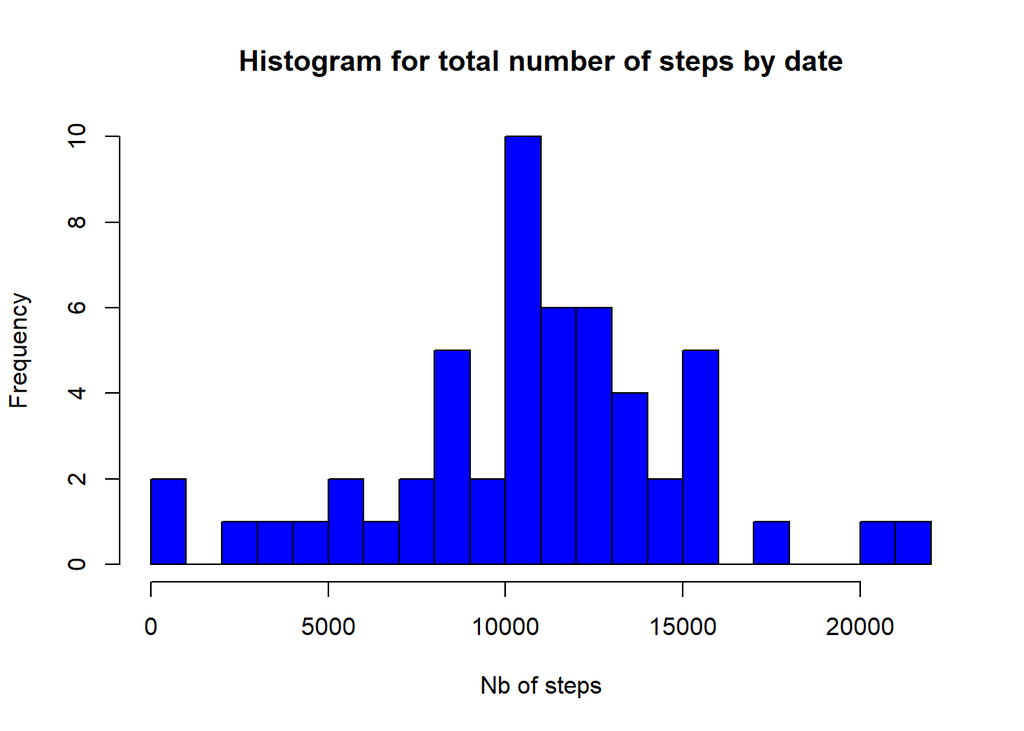

```r
hist(TotalStepsPerDay$NbSteps,breaks=seq(0,22000,1000),col="blue",main="Histogram for total number of steps by date", xlab="Nb of steps")
```

## What is the average daily activity pattern?

1.Time series plot (type = “l”) of the 5-minute interval (x-axis) and the average number of steps taken, averaged across all days (y-axis)

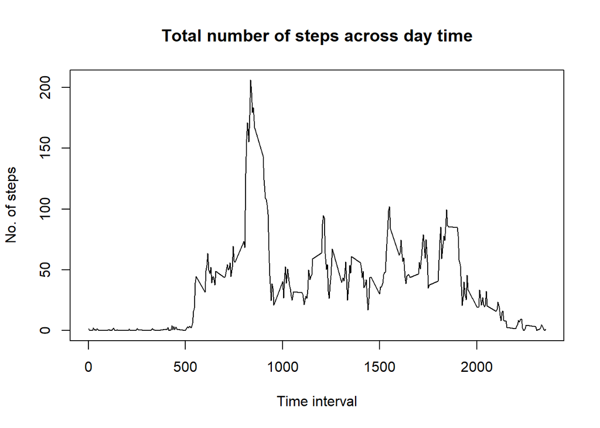

```r
AvgStepsPerTimePeriod <- aggregate(list(NbSteps = table_activity_Clean$Steps), by = list(TimeInterval=table_activity_Clean$TimeInterval),FUN = mean)
AvgStepsPerTimePeriod <- aggregate(list(NbSteps = table_activity_Clean$Steps), by = list(TimeInterval=table_activity_Clean$TimeInterval),FUN = mean)
with(AvgStepsPerTimePeriod,plot(NbSteps ~TimeInterval, xlab="Time interval", ylab="No. of steps", type="l", main="Total number of steps across day time"))
```

2. Which 5-minute interval, on average across all the days in the dataset, contains the maximum number of steps?

```r
AvgStepsSorted <- arrange(AvgStepsPerTimePeriod, desc(NbSteps))
timeIntervel <- AvgStepsSorted$TimeInterval[1]
maxSteps <- AvgStepsSorted$NbSteps[1]
```

0835 has the maximum number 206.1698113 of steps.

## Imputing missing values

There are a number of days/intervals where there are missing values (coded as NA). The presence of missing days may introduce bias into some calculations or summaries of the data.

1. Below code colculate the total number of missing values in the dataset.

```r
table_activity_Missing <- filter(table_activity,!complete.cases(table_activity))
NbMissingValues = dim(table_activity_Missing)[1]
```

Total numberof missing values in Activity dataset are: 2304

```r
MergeDF <- inner_join(AvgStepsPerTimePeriod,table_activity, by= c("TimeInterval"))
MergeDF <- MergeDF %>% mutate(Steps = ifelse(is.na(Steps), NbSteps,Steps))
```

3. A new dataset that is equal to the original dataset but with the missing data filled in.

```r
TotalStepsPerDayNew <- aggregate(list(stepsUpdated = MergeDF$Steps), by = list(ActivityDate=MergeDF$ActivityDate),FUN = sum)
print(summary(TotalStepsPerDayNew))
```

```
##   ActivityDate         stepsUpdated
##  Min.   :2012-10-01   Min.   :   41
##  1st Qu.:2012-10-16   1st Qu.: 9819
##  Median :2012-10-31   Median :10766
##  Mean   :2012-10-31   Mean   :10766
##  3rd Qu.:2012-11-15   3rd Qu.:12811
##  Max.   :2012-11-30   Max.   :21194
```

The mean and median values are now identical. This means that our transformation smoothed the values.

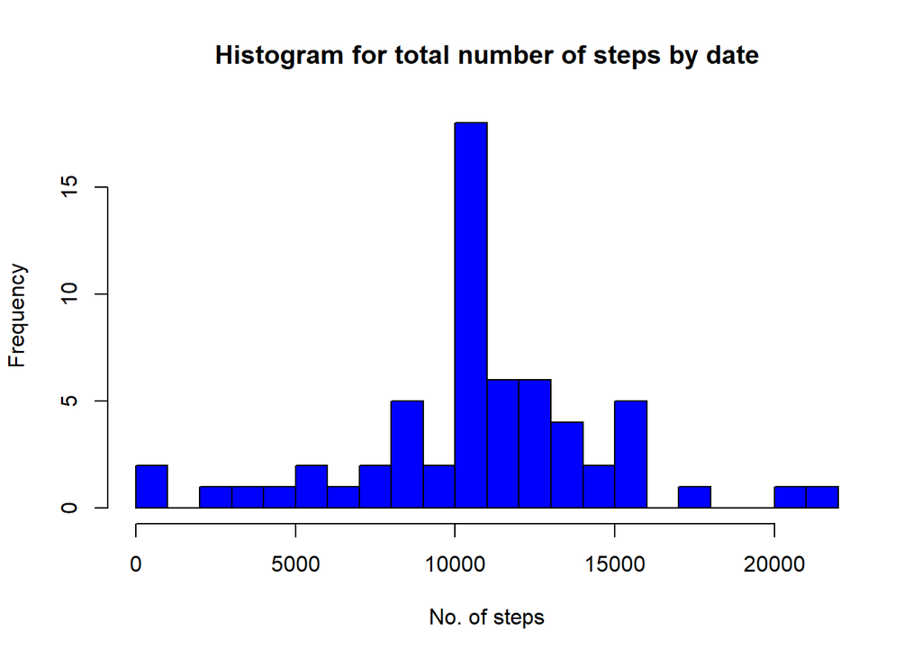

```r
hist(TotalStepsPerDayNew$stepsUpdated,breaks=seq(0,22000,1000),col="blue",main="Histogram for total number of steps by date", xlab="No. of steps")
```

## Are there differences in activity patterns between weekdays and weekends?

1. Create a new factor variable in the dataset with two levels – “weekday” and “weekend” indicating whether a given date is a weekday or weekend day.

```r
MergeDF_WDay <- MergeDF %>% mutate(WDay_WE = as.factor(ifelse(wday(ActivityDate) %in% c(1,7),"Week-End","WeekDay")))
```

2. Make a panel plot containing a time series plot (i.e. type=“l”) of the 5-minute interval (x-axis) and the average number of steps taken, averaged across all weekday days or weekend days (y-axis).

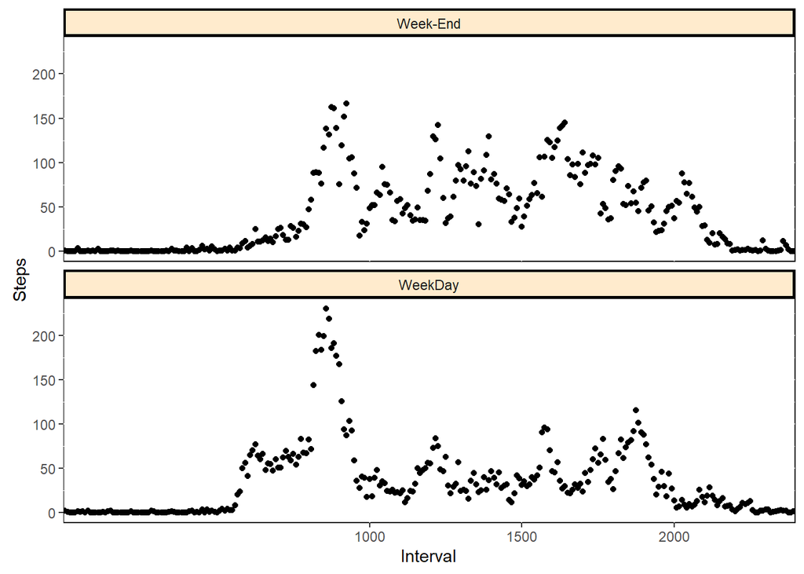

```r
library(ggplot2)
MergeDF_WDay <- MergeDF %>% mutate(WDay_WE = as.factor(ifelse(wday(ActivityDate) %in% c(1,7),"Week-End","WeekDay")))
MergeDF_WDay_Mean <- aggregate(list(Steps = MergeDF_WDay$Steps), by = list(WDay_WE =MergeDF_WDay$WDay_WE,TimeInterval=MergeDF_WDay$TimeInterval),FUN = mean)

g1 <- ggplot(MergeDF_WDay_Mean, aes(x=TimeInterval,y=Steps))
g1 <- g1 + geom_point() + facet_grid(.~WDay_WE) + theme(strip.background = element_rect(colour="black", fill="BlanchedAlmond", size=1.5, linetype="solid"),
                                                   panel.background= element_rect(fill="white", linetype="solid",colour="black"))
g1 <- g1 + facet_wrap(~WDay_WE,nrow = 2) + scale_x_discrete(name="Interval", breaks = c(0,500,1000,1500,2000,2500),labels = c(0,500,1000,1500,2000,2500))
print(g1)
```